# Exploring white wine data by Krishna Ganapathi

```
## [1] "C:/Users/Krishna/Desktop/udacity projects/p4/p4project"
```

```
##   X fixed.acidity volatile.acidity citric.acid residual.sugar chlorides
## 1 1           7.0             0.27        0.36           20.7     0.045
## 2 2           6.3             0.30        0.34            1.6     0.049
## 3 3           8.1             0.28        0.40            6.9     0.050
## 4 4           7.2             0.23        0.32            8.5     0.058
## 5 5           7.2             0.23        0.32            8.5     0.058
## 6 6           8.1             0.28        0.40            6.9     0.050
##   free.sulfur.dioxide total.sulfur.dioxide density   pH sulphates alcohol
## 1                  45                  170  1.0010 3.00      0.45     8.8
## 2                  14                  132  0.9940 3.30      0.49     9.5
## 3                  30                   97  0.9951 3.26      0.44    10.1
## 4                  47                  186  0.9956 3.19      0.40     9.9
## 5                  47                  186  0.9956 3.19      0.40     9.9
## 6                  30                   97  0.9951 3.26      0.44    10.1
##   quality
## 1       6
## 2       6
## 3       6
## 4       6
## 5       6
## 6       6
```

We are using a dataset in order to figure out what qualities affect the acidic property of white wines. The data that we have loaded consist of white wines and the breakdown of its compnents, The components are discussed more below. We can see that all inputs are numeric in nature. This allows us to work with a cleaner dataset and we don’t have to do any extra cleaning of the data.

# Univariate Plots Section

The components we see below are the key category compositions of several white wines. We have fixed acidity, volatile acidity and citric acid. furhter more we have sugar, chlorides, and sulfur dioxide. Finally we have density, PH, sulfates, alcohol content and the quality of the wine. We will see how these categories influence the quality of the wines.

```
##        X        fixed.acidity    volatile.acidity  citric.acid
##  Min.   :   1   Min.   : 3.800   Min.   :0.0800   Min.   :0.0000
##  1st Qu.:1225   1st Qu.: 6.300   1st Qu.:0.2100   1st Qu.:0.2700
##  Median :2450   Median : 6.800   Median :0.2600   Median :0.3200
##  Mean   :2450   Mean   : 6.855   Mean   :0.2782   Mean   :0.3342
##  3rd Qu.:3674   3rd Qu.: 7.300   3rd Qu.:0.3200   3rd Qu.:0.3900
##  Max.   :4898   Max.   :14.200   Max.   :1.1000   Max.   :1.6600
##  residual.sugar     chlorides       free.sulfur.dioxide
##  Min.   : 0.600   Min.   :0.00900   Min.   :  2.00
##  1st Qu.: 1.700   1st Qu.:0.03600   1st Qu.: 23.00
##  Median : 5.200   Median :0.04300   Median : 34.00
##  Mean   : 6.391   Mean   :0.04577   Mean   : 35.31
##  3rd Qu.: 9.900   3rd Qu.:0.05000   3rd Qu.: 46.00
##  Max.   :65.800   Max.   :0.34600   Max.   :289.00
##  total.sulfur.dioxide    density             pH          sulphates
##  Min.   :  9.0        Min.   :0.9871   Min.   :2.720   Min.   :0.2200
##  1st Qu.:108.0        1st Qu.:0.9917   1st Qu.:3.090   1st Qu.:0.4100
##  Median :134.0        Median :0.9937   Median :3.180   Median :0.4700
##  Mean   :138.4        Mean   :0.9940   Mean   :3.188   Mean   :0.4898
##  3rd Qu.:167.0        3rd Qu.:0.9961   3rd Qu.:3.280   3rd Qu.:0.5500
##  Max.   :440.0        Max.   :1.0390   Max.   :3.820   Max.   :1.0800
##     alcohol         quality
##  Min.   : 8.00   Min.   :3.000
##  1st Qu.: 9.50   1st Qu.:5.000
##  Median :10.40   Median :6.000
##  Mean   :10.51   Mean   :5.878
##  3rd Qu.:11.40   3rd Qu.:6.000
##  Max.   :14.20   Max.   :9.000
```

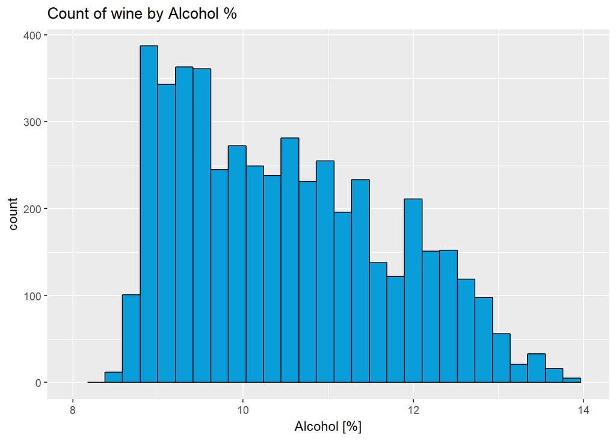

Most of the wines with the highest alcohol content happen between intervals. We can almost see a bimodal distribution.

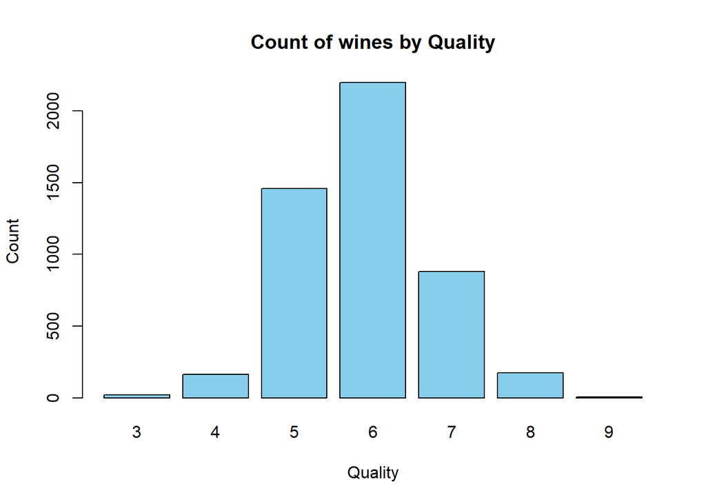

This is pretty much a normal distribution. we see that most wines have a quality between 5 and 7 (inclusive). The middle value of 6 is associated with the highest count of wines.

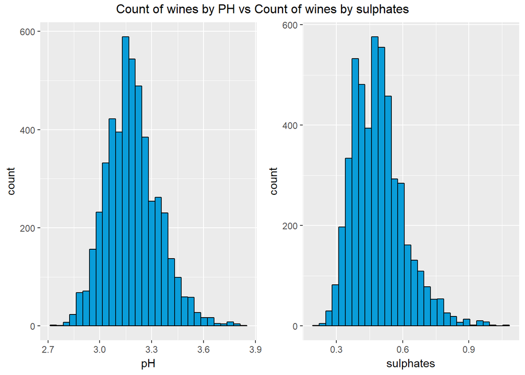

Again we see something expected. knowin that alcohol in general is acidic I didn’t expect to see this go past 5 or 6 on the PH scale. Our data shows that all of our data is less than 4 and clusters around a PH of 3.1-3.2.

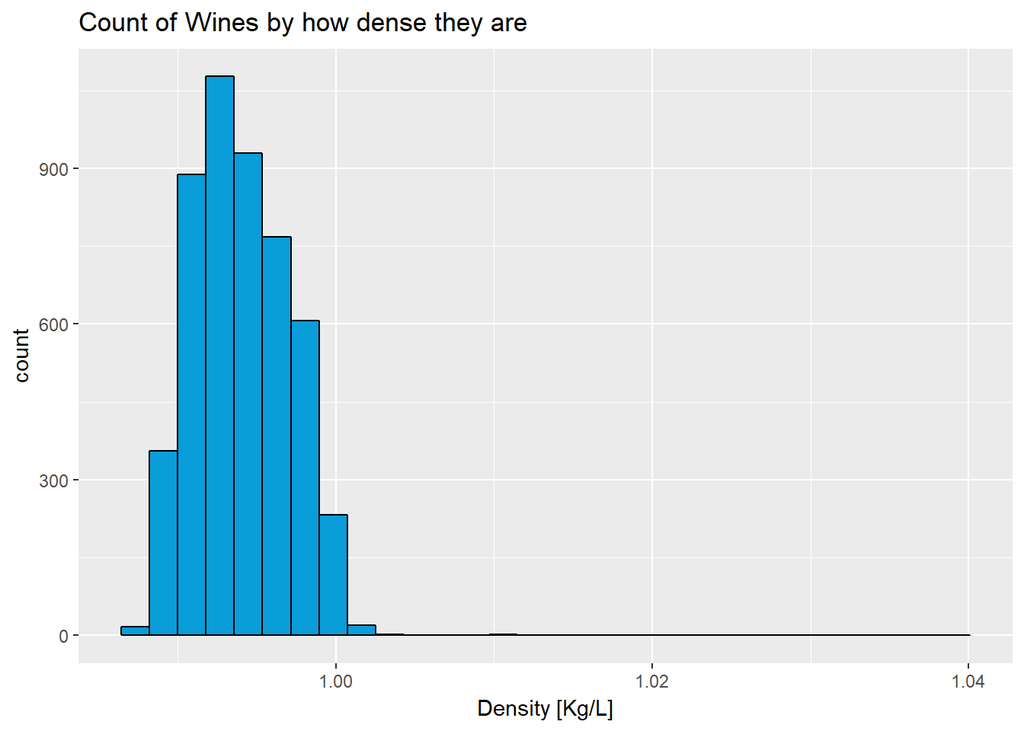

This surprised me a little bit but upon further research I found that wines are mostly water so the density of wines should be similar to the density of water which is 1.000 Kg/L. Dry wines are even less dense; we see a greater density in wines and this might be because of alchol and sugar content.

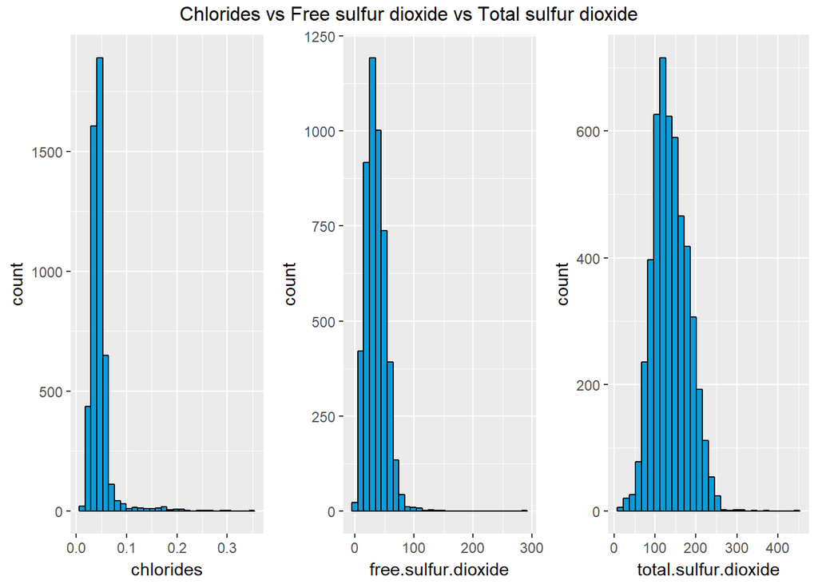

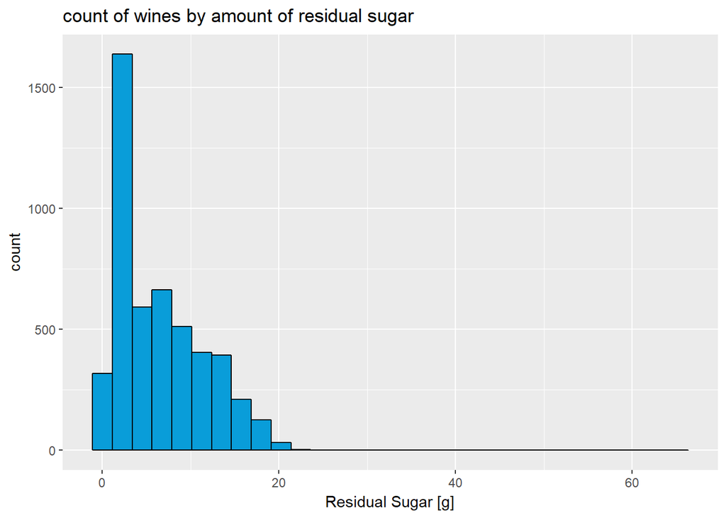

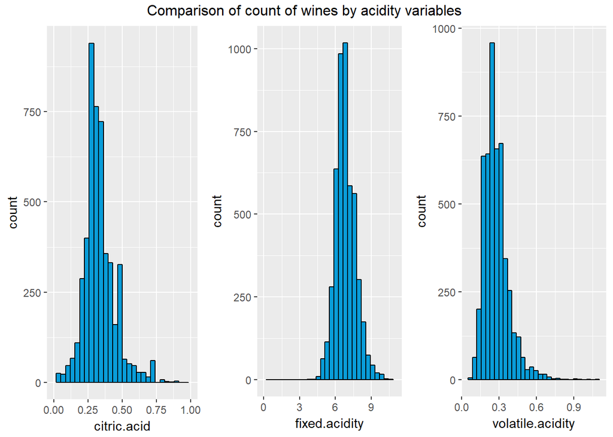

# Univariate Analysis

### What is the structure of your dataset?

The structure of my Dataset is closed having several key variables. These variables are all continuous within their distributions.

### What is/are the main feature(s) of interest in your dataset?

The main features of interest in my dataset are alcohol content, density, acidity, and sulfate content. I believe that these variables are the variables that will help me find the answer to the question proposed during the introduction of “what qualities affect the acidic property of wines.”.

### What other features in the dataset do you think will help support your investigation into your feature(s) of interest?

I think that an investigation into how residual sugar affects the acidity will help support my findings.

### Did you create any new variables from existing variables in the dataset?

I did not create any new variables in the dataset.

### Of the features you investigated, were there any unusual distributions? Did you perform any operations on the data to tidy, adjust, or change the form of the data? If so, why did you do this?

Upon analysis of the data, I found that the data was clean enough to start plotting with. I did some cleaning while plotting the data on various plots to get the most useful data on the plots.

# Bivariate Plots Section

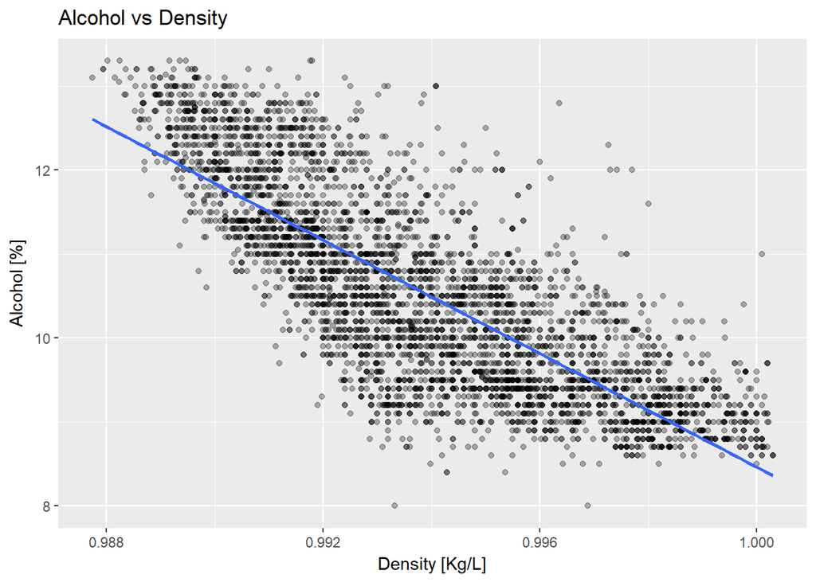

```
## [1] -0.7801376
```

I wanted to look at alcohol vs Density but this graph doesn’t tell us much. I added the correlation function to see how closely the 2 variables are related to each other and we get a correlation of -.78. This is a strong correlation because strong correlations are either > .7 or < -.7. I would like to see how other variables will affect this graph in my analysis.

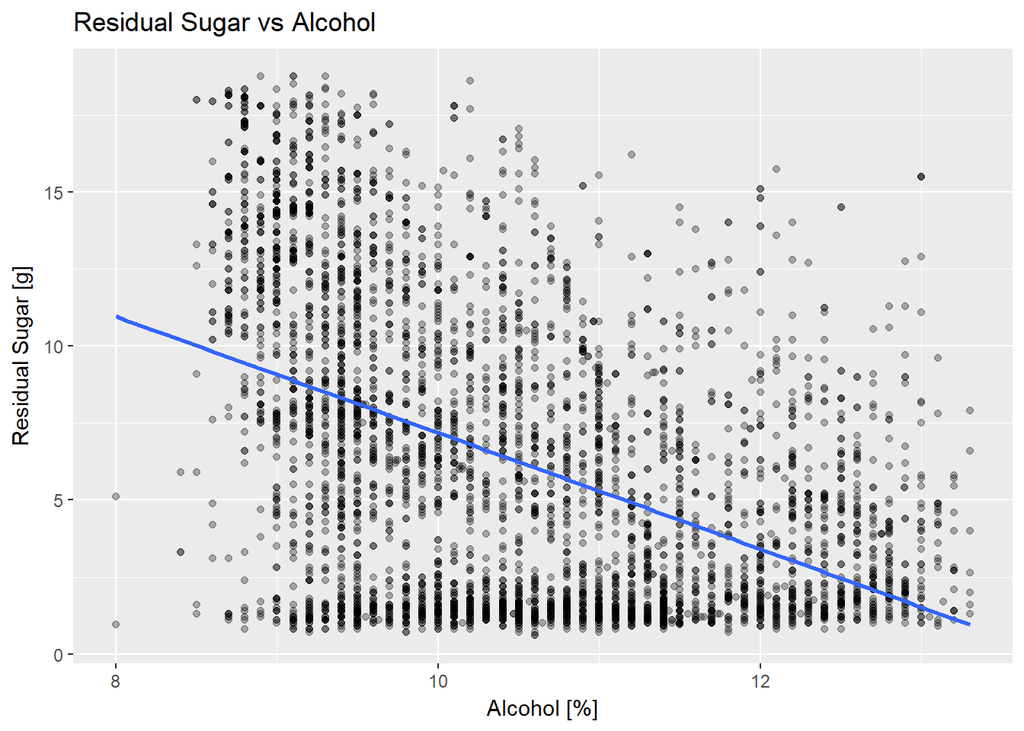

I wanted to now see how residual sugar and alcohol effects quality.

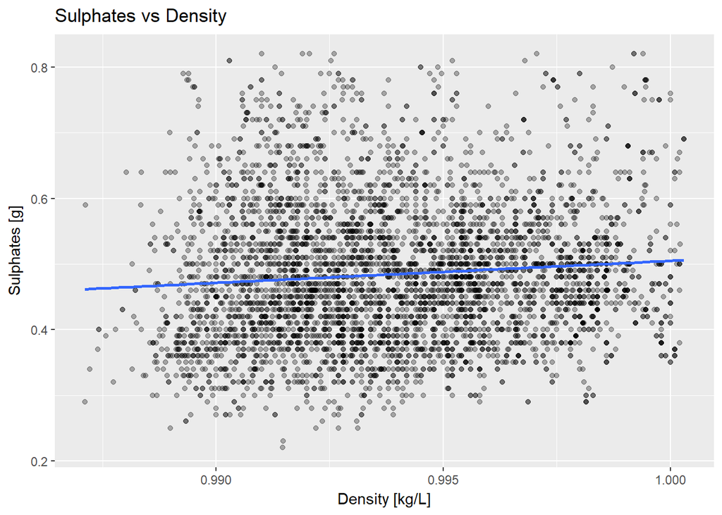

I really had the feeling that density and sulphates had a bigger influence on all aspects of wine acidity and I wanted to really eplore this here in this section.

# Bivariate Analysis

### Talk about some of the relationships you observed in this part of the investigation. How did the feature(s) of interest vary with other features in the dataset?

Following this I wanted to see how density and sulphates affect quality. I have a feeling that acidity goes up as density and sulphates go down.

### Did you observe any interesting relationships between the other features (not the main feature(s) of interest)?

I did not observe any other relationships.

# Multivariate Plots Section

Building upon the graphs in the previous section I wanted to see how much further I can analyze these variables

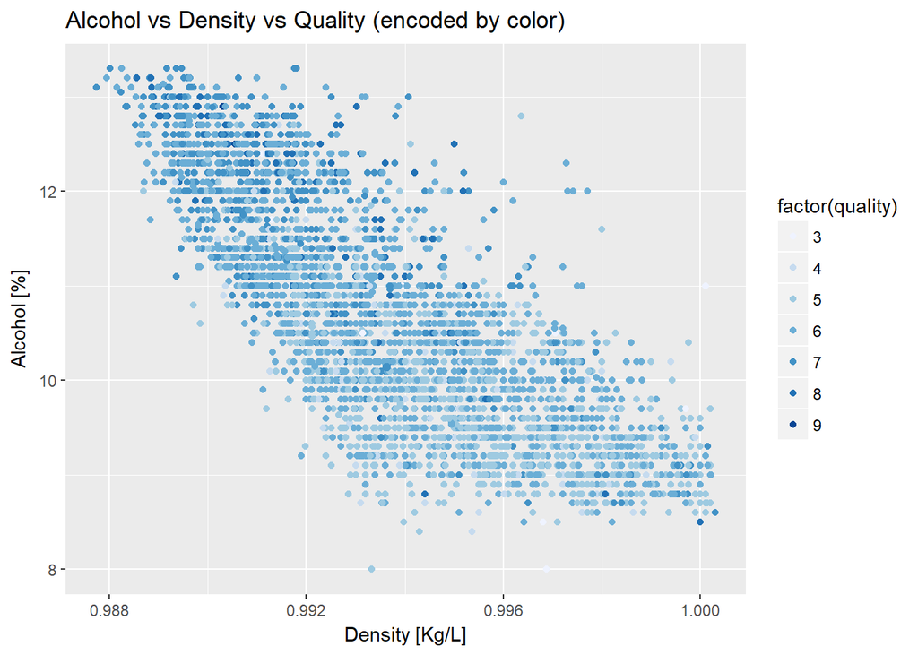

I went ahead and colored it in by quality. This tells me that as the alcohol level goes up and density goes down the quality goes up. I have a feeling that people just like a lot of alcohol that is easy to drink.

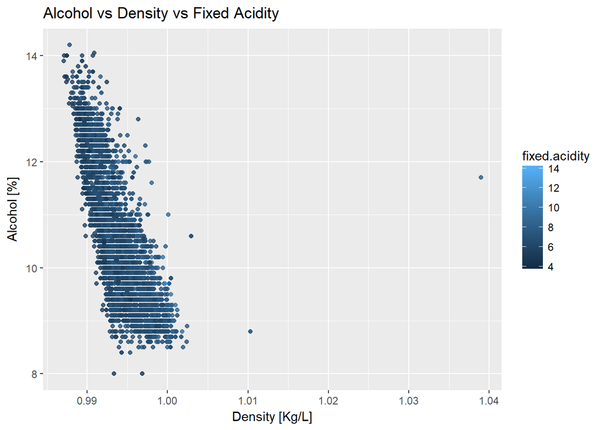

fixed acidity also is in line with the quality analysis from above. As the alcohol level goes up the fixed acidity level goes down.

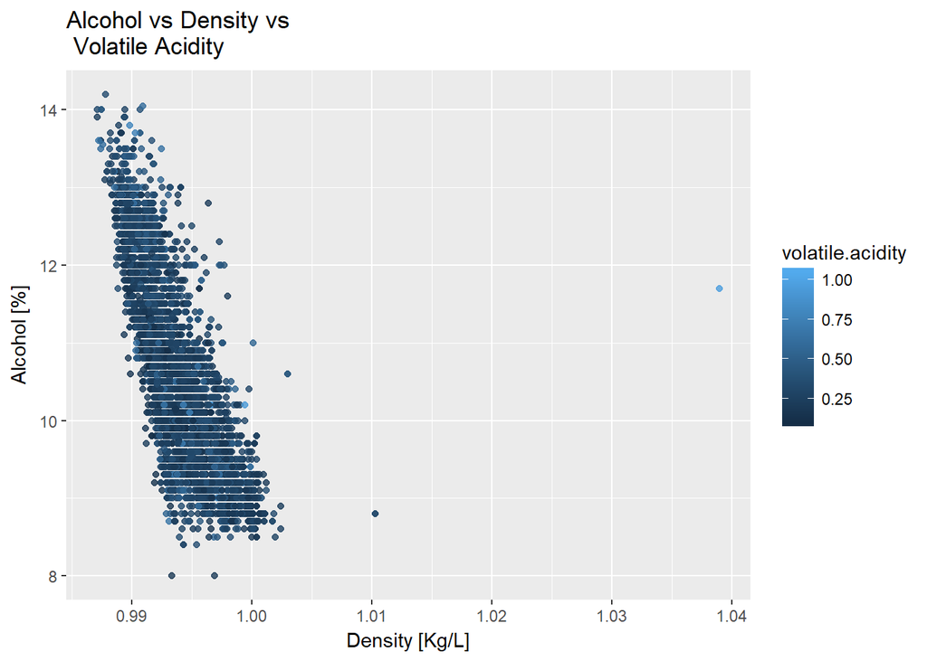

volatile acidity also follows suit. we can see acidity show up more in wines that are higher in density and lower in alcohol content.

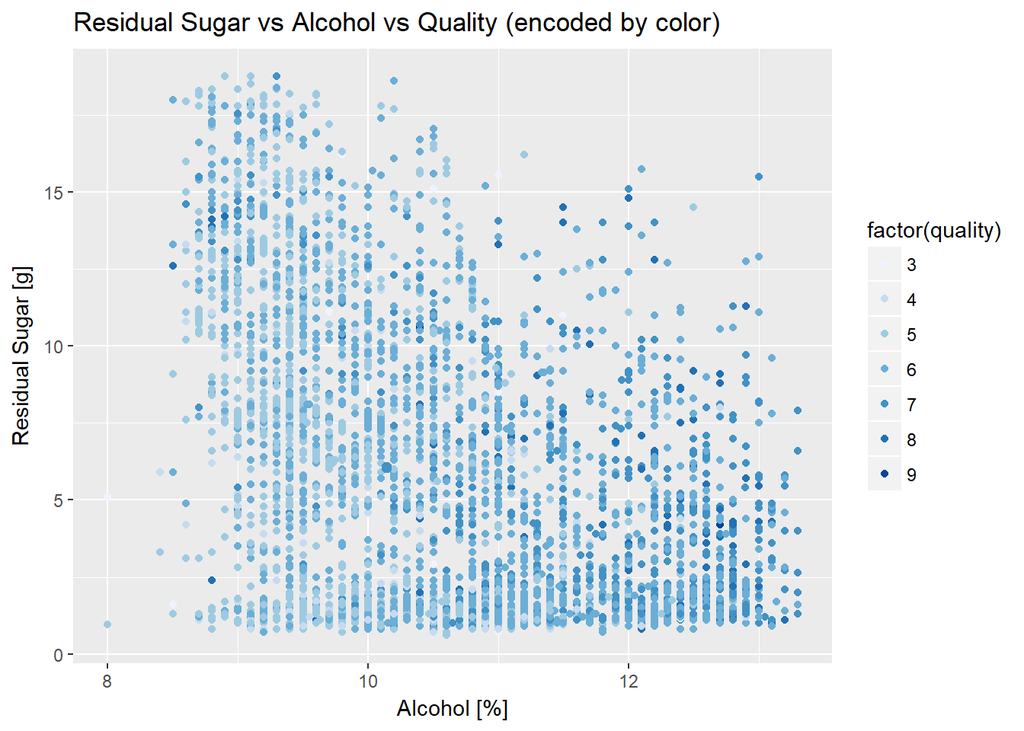

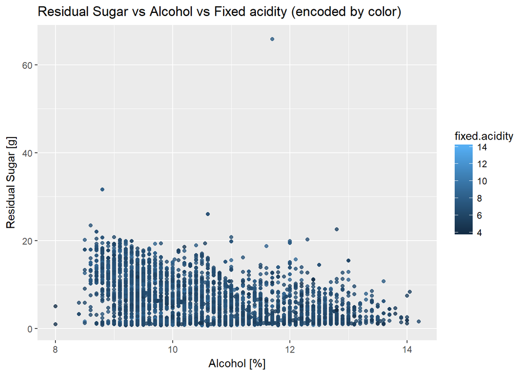

Here I wanted to see what effect residual sugar and alcohol had on fixed acidity. Fixed acidity was the strongest when the alcohol content was around 10 this could have been because the grapes that were picked were grown in an environment that made them more acidic.

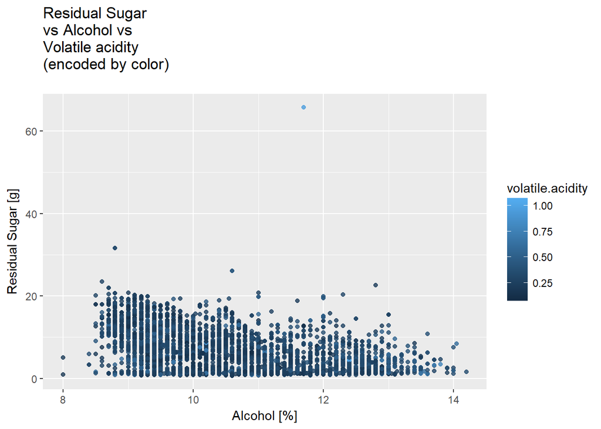

Here I wanted to see what effect residual sugar and alcohol had on volatile acidity. As you can see volatile acidity increased as either alcohol content increased or sugar content increased.

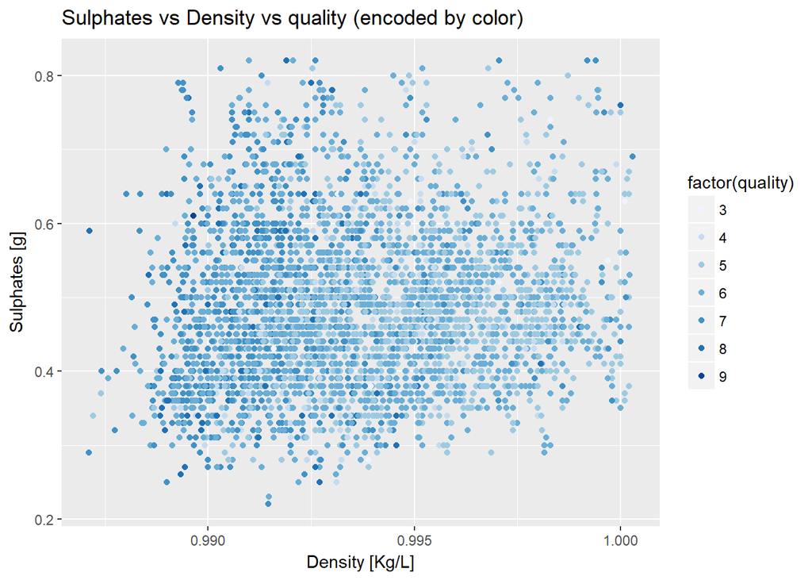

here we can see that the quality is higher as the sulphates and the density is lower.

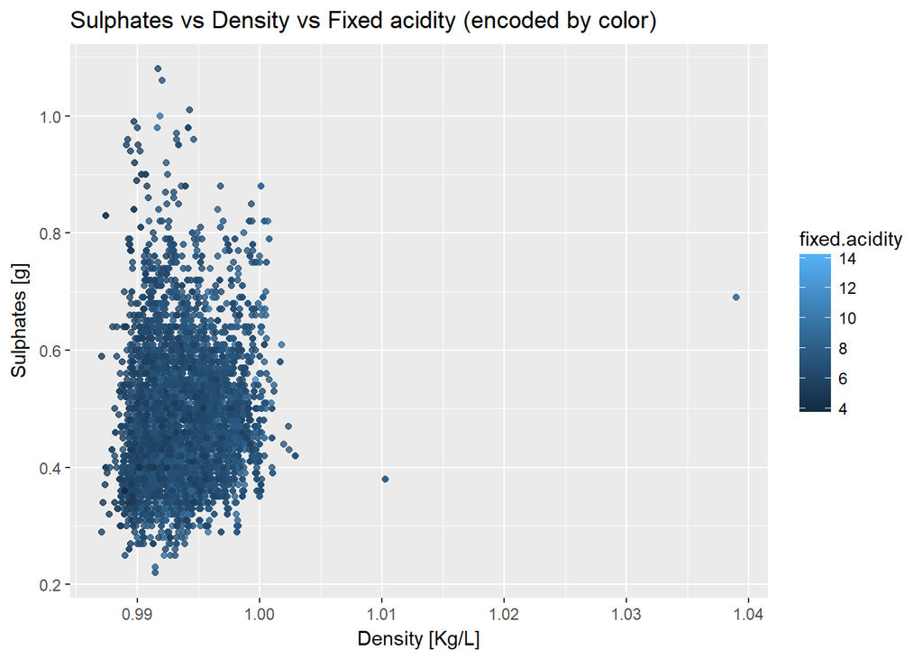

[figure not shown]

we see here that volatile acidity stays more constant as density and sulphates change. We see the greatest density of blue clustered closer towards a little right of center.

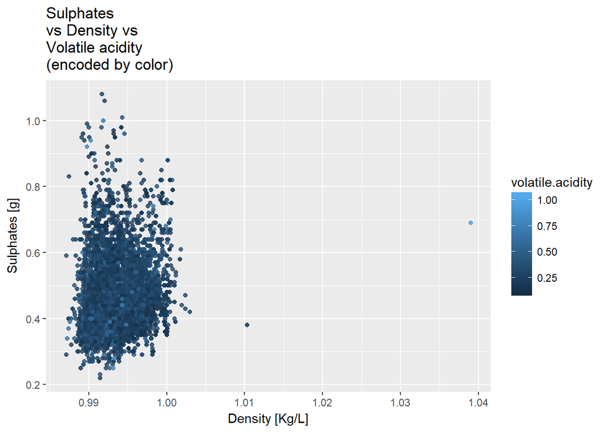

In case my eyes were tricking me I wanted to know if my conclusion above was correct.

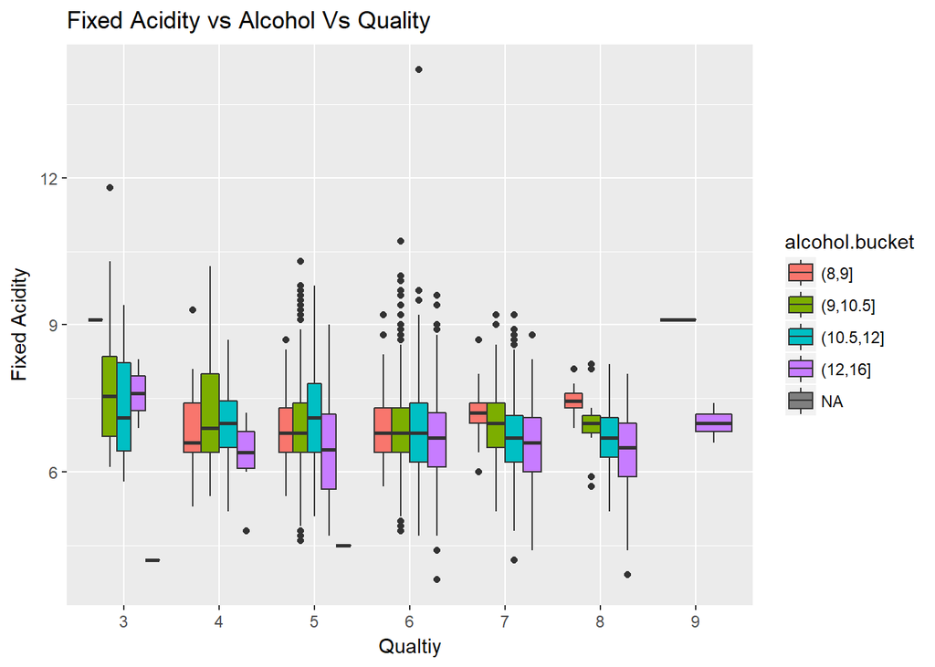

The higher the quality of wines we also get a higher alcohol content and closer to 7 for fixed acidity

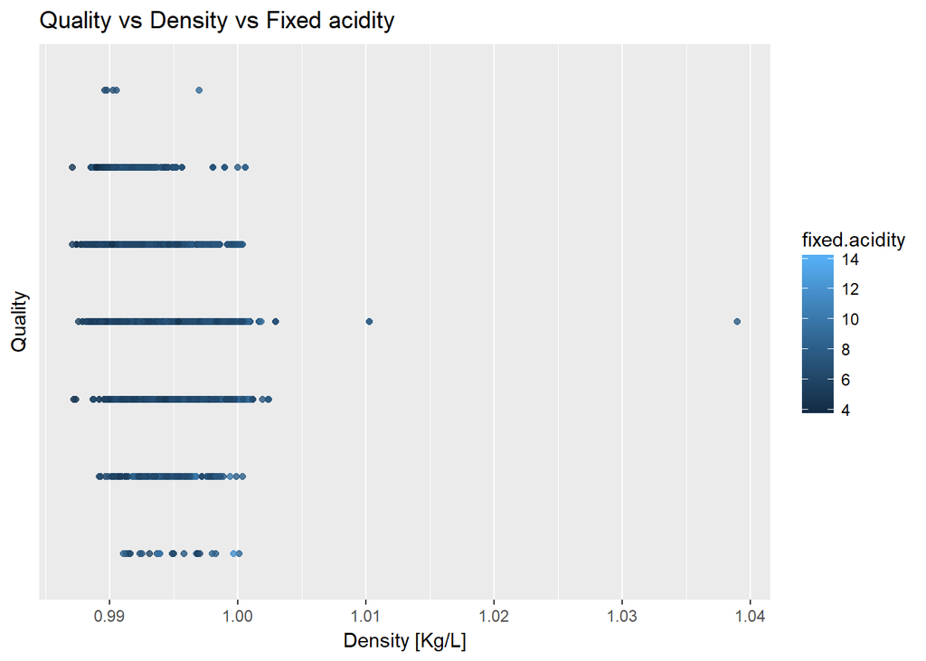

higher the quality of wines the lower the density and the more closer to 7 for the level of fixed acidity

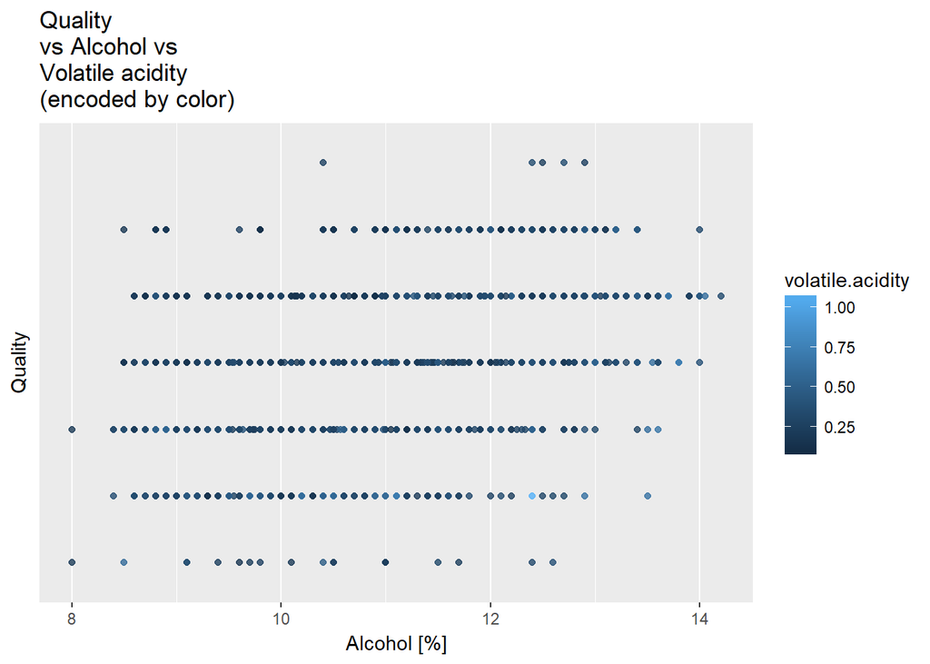

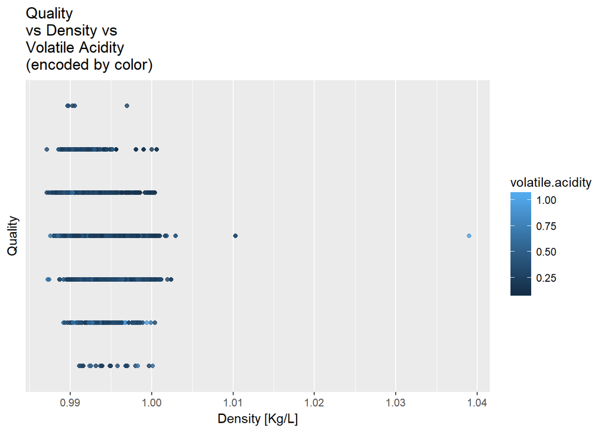

Quality and volatile acidity both go up as density goes down.

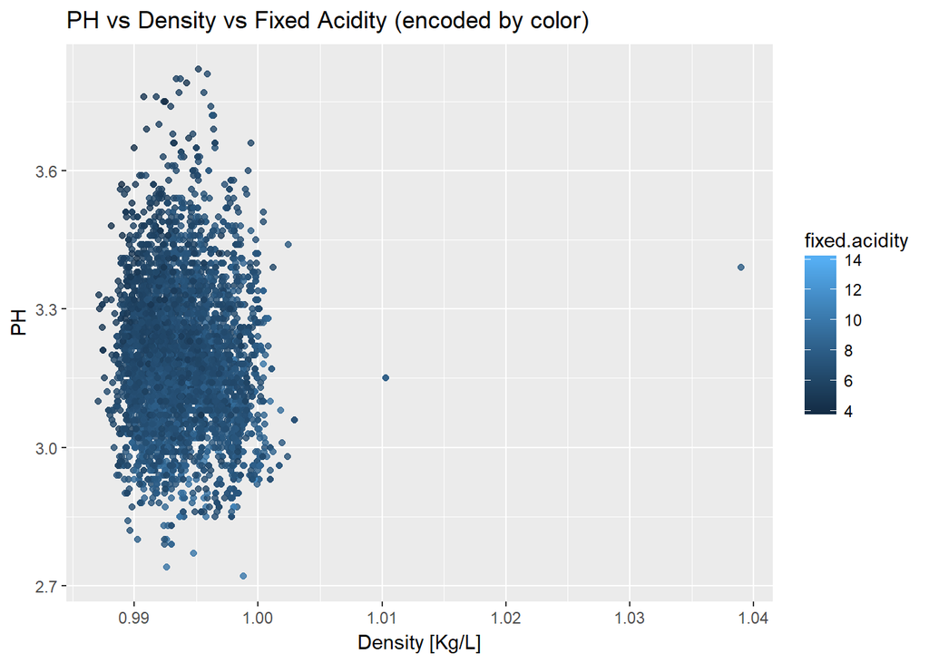

As fixed acidity goes up as PH goes down and density goes down.

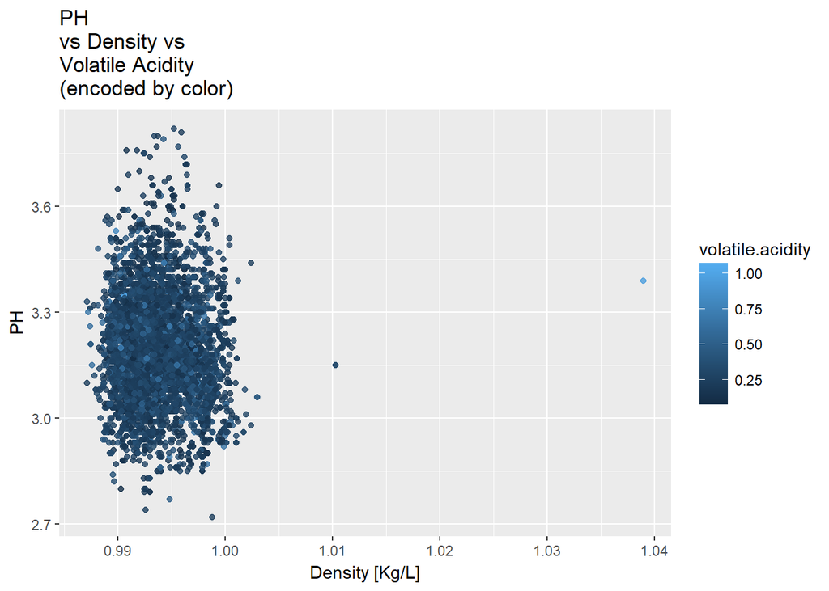

Volatile acidity also goes up as PH & density goes down.

# Multivariate Analysis

### Talk about some of the relationships you observed in this part of the investigation. Were there features that strengthened each other in terms of looking at your feature(s) of interest?

Revisiting what effects density and sulphates have on acidity, I observed that as fixed acidity goes up density and sulphates go down. But upon closer inspection we see that fixed acidity goes up as either density or sulphates are low.

### Were there any interesting or surprising interactions between features?

No I did not find any interesting or surprising interactions between features. I had a couple of hunches from the bivarate analysis section and those hunches turned out to be true.

### OPTIONAL: Did you create any models with your dataset? Discuss the strengths and limitations of your model.

I did not create any new models in my dataset.

# Final Plots and Summary

### Plot One

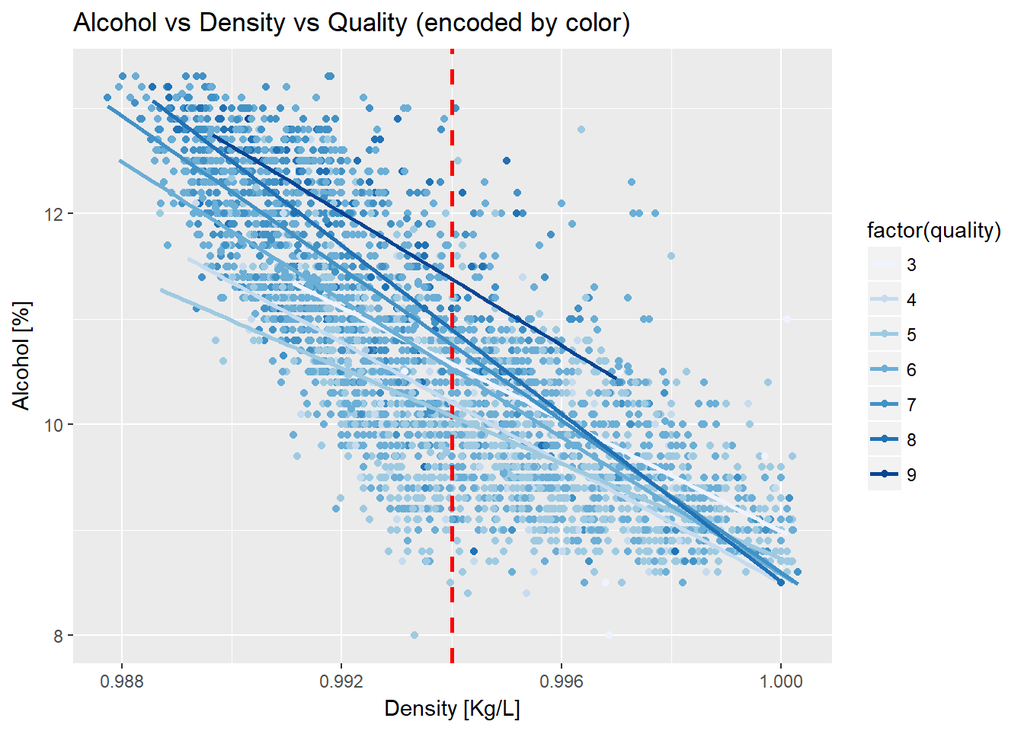

I Picked this plot because it told me the heart of what was in the data set. I wanted to know how quality is affected given alcohol and density and this graph is very clear about that. Quality goes up as Alcohol goes up and density goes down.

### Plot Two

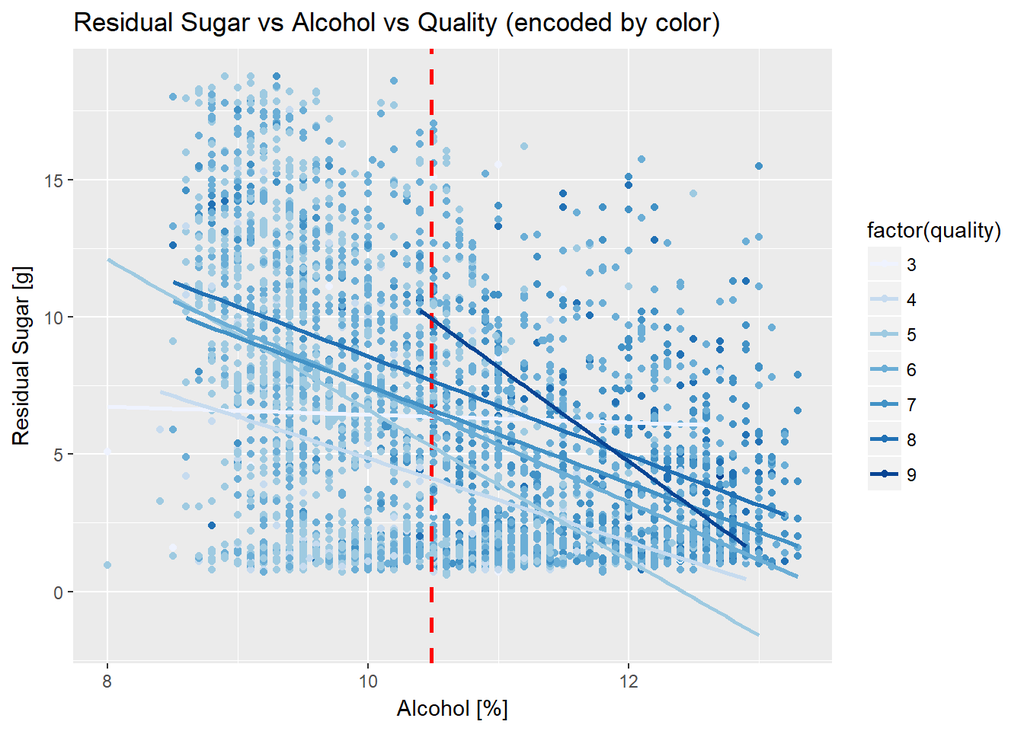

### Plot Three

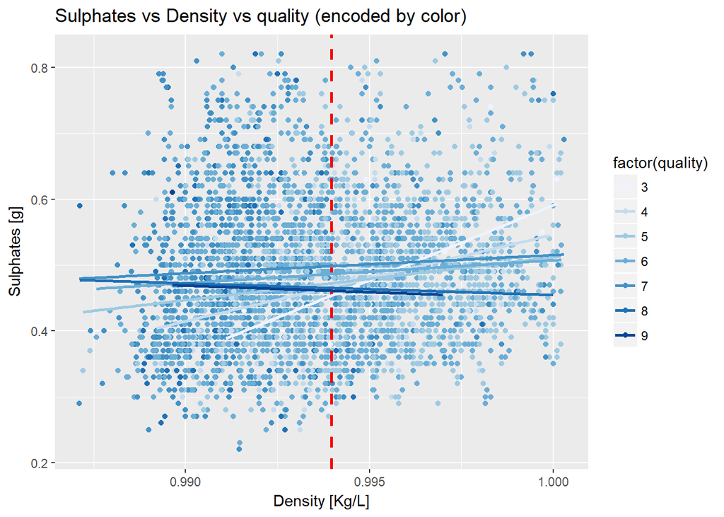

# Reflection

I came into this project really excited about the undertaking of it. The biggest Challenge I had while working throughout this project was making sure that I was following my analysis consistently. I would get a new idea and graph it but i had to keep asking myself if the graph I was getting was pertinent to my discussion and what I was trying to explore and the questions I was trying to answer. I also took a while to complete this project because I was offered a job back in march but the struggle of not having a solid housing situation for a while and moving from location to location made this project even more arduous to complete.

What went well was my initial single variable analysis of the project. I was able to draw from memory all of the code needed. I required some help for the bivariate and multivariate parts. I think what was surprising was that Acidity stayed relatively constant despite influences from sugar, sulphates and alcohol. I also thought that a higher acidity would mean that the quality would go down but the quality was more correlated with alcohol than any of the other variables.

I think what we can do more with the data set is figure out which of these factors influence alcohol content and by how much alcohol content varies across investigations given different factors.